# Validation of Cairns_Cooktown’s EOMAP depth layers derived from Landsat and Sentinel vs acoustic validation data

This document shows regression plots between EOMAP depth layer derived from Landsat (EOMAP_Landsat) vs acoustic validation data and EOMAP depth layer derived from Sentinel (EOMAP_Sentinel) vs acoustic validation data. The figure below shows the location of acoustic validation data.

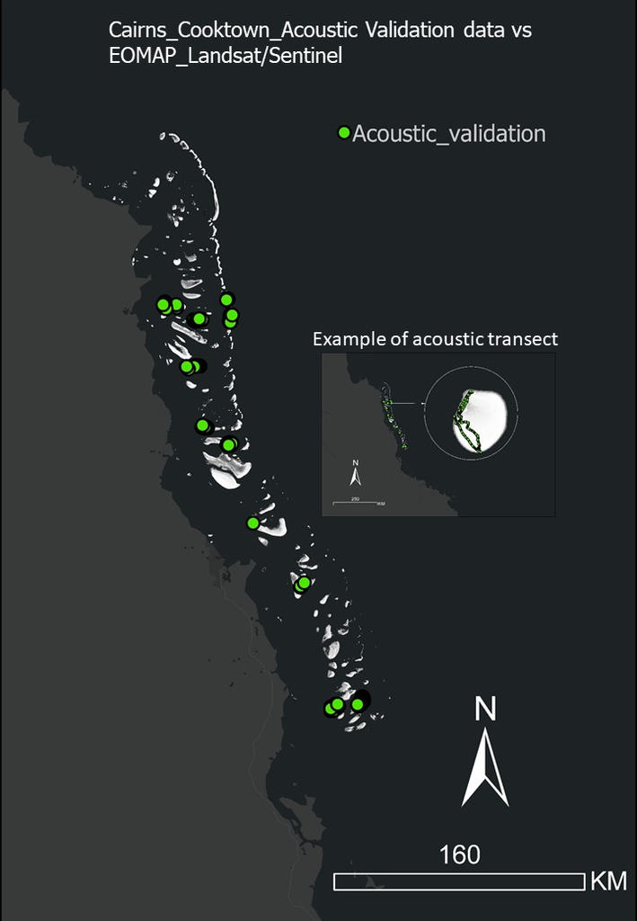

Fig. 1. Location of acoustic data collected in Cairns-Cooktown (GBR)

- **EOMAP Landsat depth vs acoustic data (all data)**

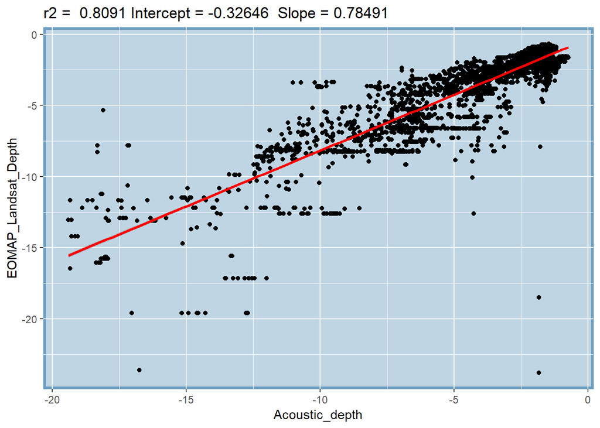

- **EOMAP Sentinel depth vs acoustic data (all data)**

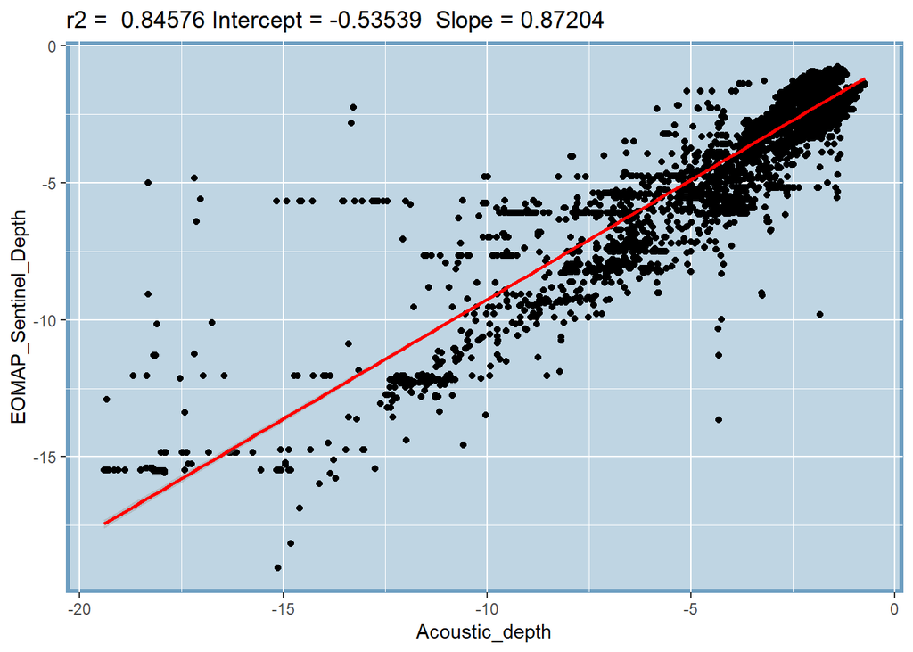

- **EOMAP Landsat depth vs acoustic data (0-3 meter subset)**

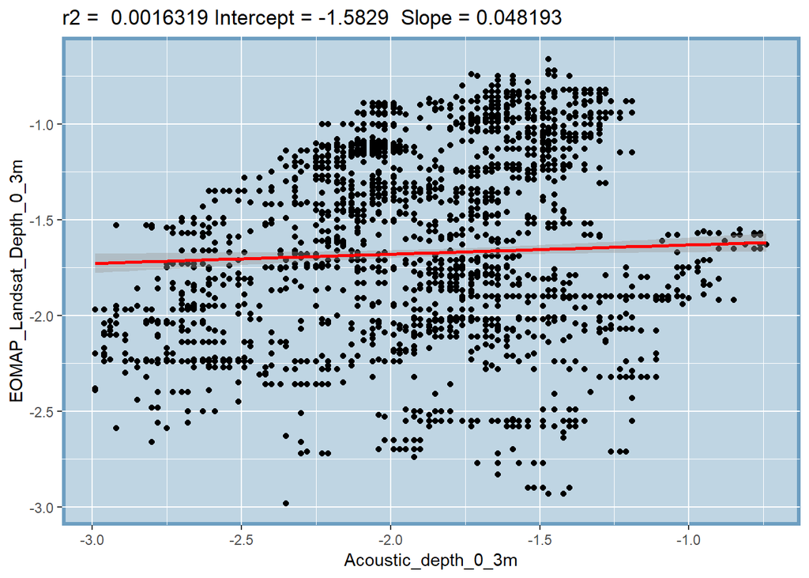

- **EOMAP Sentinel depth vs acoustic data (0-3 meter subset)**

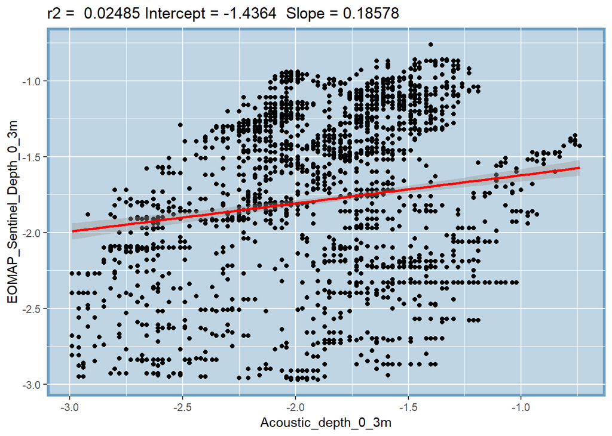

- **EOMAP Landsat depth vs acoustic data (0-5 meter subset)**

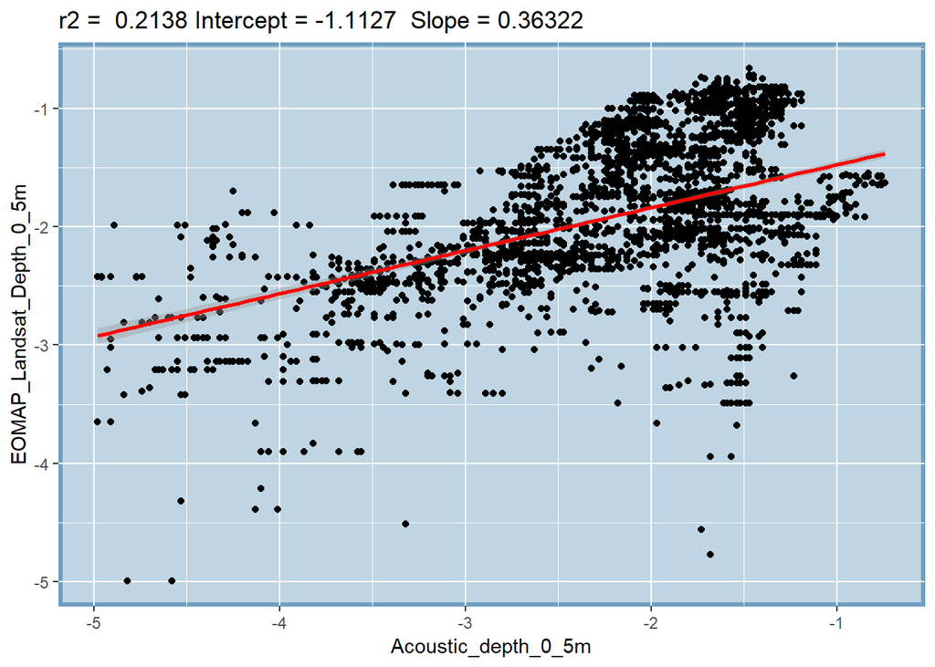

- **EOMAP Sentinel depth vs acoustic data (0-5 meter subset)**

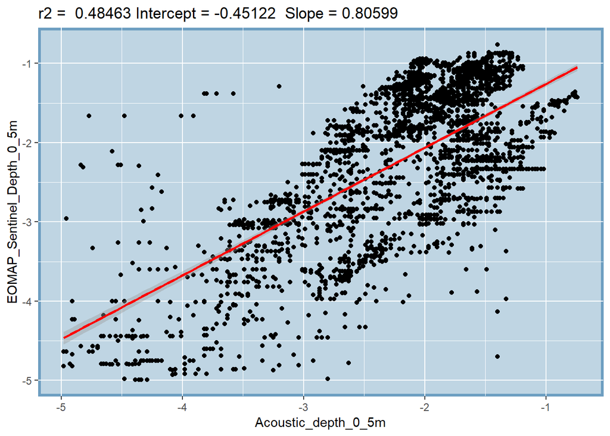

- **EOMAP Landsat depth vs acoustic data (0-10 meter subset)**

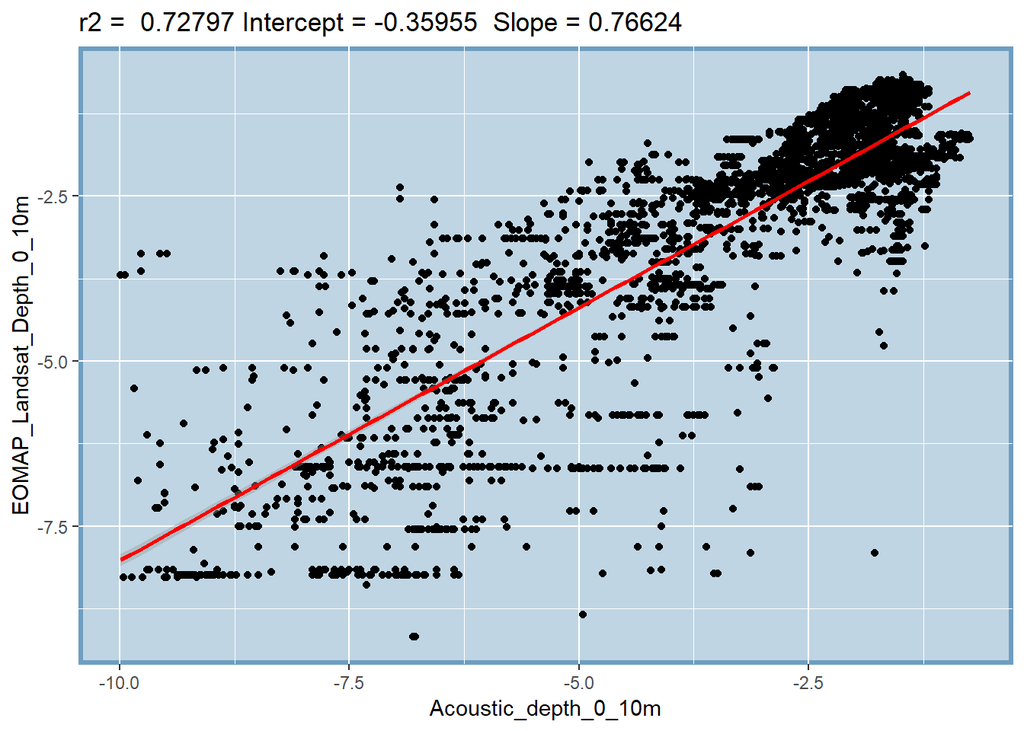

- **EOMAP Sentinel depth vs acoustic data (0-10 meter subset)**

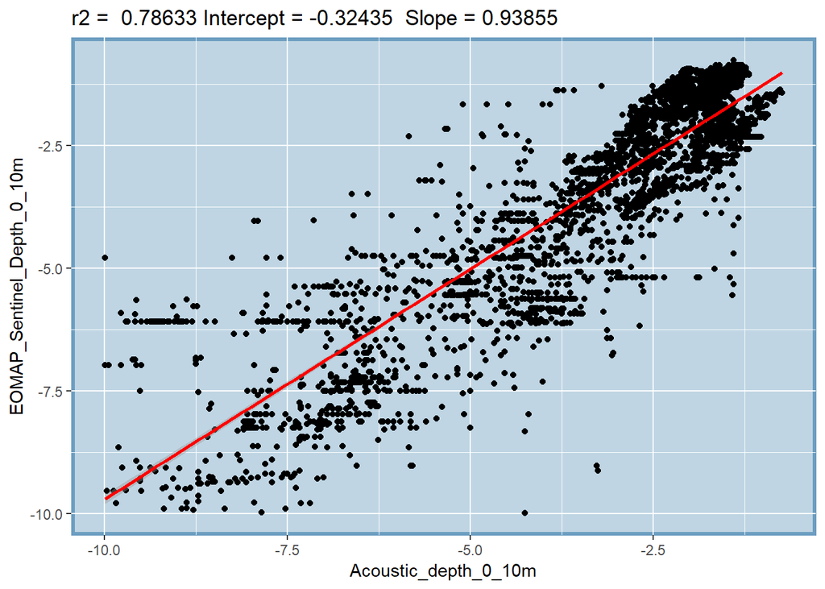

- **EOMAP Landsat depth vs acoustic data (0-15 meter subset)**

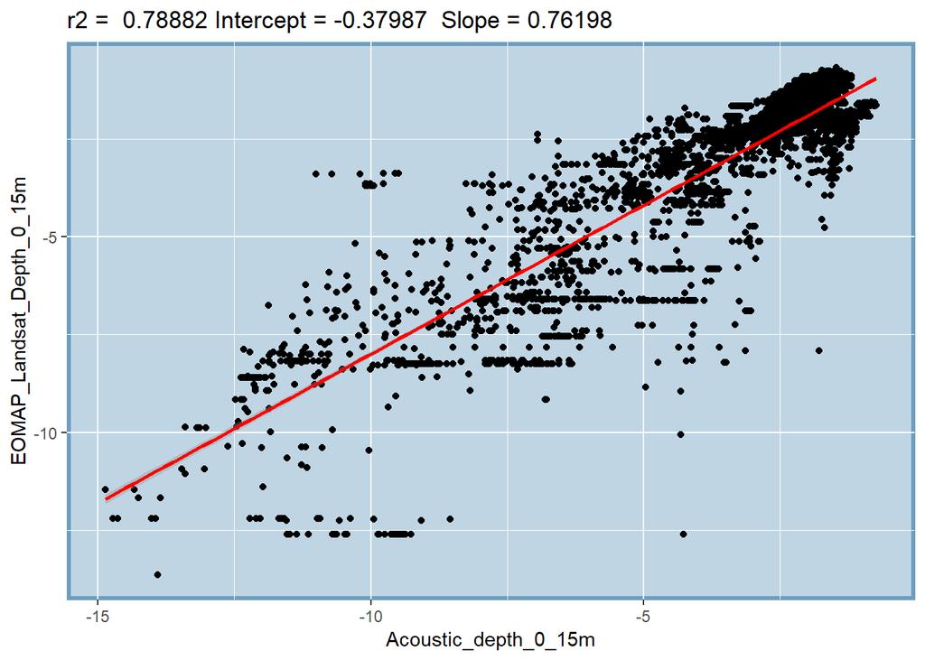

- **EOMAP Sentinel depth vs acoustic data (0-15 meter subset)**

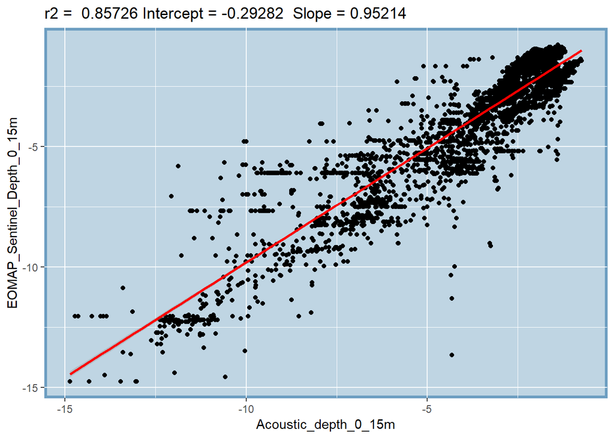